# The QuakeScope picker benchmarks, consolidated

Five notebooks benchmark the pickers behind the 2026 catalogue, each against a different reference and each rendered as its own report. This notebook reads their **exported result tables** (`docs/benchmark/results/`, written by an export cell at the end of each notebook when it is executed) and draws the figures a paper needs from all of them at once. Nothing is re-picked here and no number is typed in: change a benchmark, re-execute it, re-execute this.

| study | notebook | reference | result files |
| --- | --- | --- | --- |
| US sequences | `phasenet_sequence_comparison.ipynb` | reviewed ComCat events, arrivals from SCEDC + NCEDC, manual only | `us_sequences/` |
| Global sequences | `phasenet_global_sequences.ipynb` | GeoNet, INGV, NOA bulletins, manual only | `global_sequences/` |
| Ridgecrest aftershocks | `phasenet_aftershock_benchmark.ipynb` | SCEDC analyst picks, one dense 30 min window | `ridgecrest_aftershocks/` |
| Ocean bottom | `phasenet_obs_offshore_benchmark.ipynb` | iasp91 predictions; Barcheck AACSE analyst picks; UW Axial picks; LDEO ML-DD events | `obs_offshore/` |
| Western reproduction | `western_pick_validation.ipynb` | the campaign's own Parquet, re-picked via FDSN | `western_reproduction/` |

The protocol, the caveats and the reading of these figures are in [`docs/benchmark/README.md`](https://github.com/SeisSCOPED/QuakeScope/blob/main/docs/benchmark/README.md).

```python
import json
from pathlib import Path

import numpy as np
import pandas as pd
import matplotlib.pyplot as plt

RES = Path("../docs/benchmark/results")
WEIGHTS = ["quakescope2026", "jma_wc", "original", "instance"]
COLORS = dict(zip(WEIGHTS, ["#2a78d6", "#eb6834", "#1baf7a", "#eda100"]))
C_P, C_S = "#2a78d6", "#eb6834"
plt.rcParams.update({"figure.dpi": 110, "axes.grid": True, "grid.alpha": 0.25, "grid.linewidth": 0.5,
                     "axes.axisbelow": True, "axes.spines.top": False, "axes.spines.right": False})

def load(study, name):
    p = RES / study / f"{name}.csv"
    return pd.read_csv(p) if p.exists() else None

meta = {s: json.loads((RES / s / "meta.json").read_text()) for s in
        ["us_sequences", "global_sequences", "ridgecrest_aftershocks", "obs_offshore", "western_reproduction"]
        if (RES / s / "meta.json").exists()}
print("result sets and when they were executed:")
for s, m in meta.items():
    print(f"  {s:24s} {m['executed']}  seisbench {m.get('seisbench')}")
```

```
result sets and when they were executed:
  us_sequences             2026-09-16T19:41:46+00:00  seisbench 0.12.3
  global_sequences         2026-09-16T19:31:15+00:00  seisbench 0.12.3
  ridgecrest_aftershocks   2026-09-16T19:21:05+00:00  seisbench 0.12.3
  obs_offshore             2026-09-16T19:34:01+00:00  seisbench 0.12.3
  western_reproduction     2026-09-16T19:46:12+00:00  seisbench 0.12.3
```

## 1. Recall against analyst picks at the shared 0.3 threshold

Seven sequences with a published analyst reference: four in the western United States (SCEDC and NCEDC, manually reviewed picks on curated event lists) and three abroad (the operators' bulletins). Six stations per sequence abroad, five in the US; windows of 30 min to 3 h starting 10 min after the mainshock; a pick counts as recovered within 0.5 s. The number under each group is the analyst pick count, the sample size of that recall.

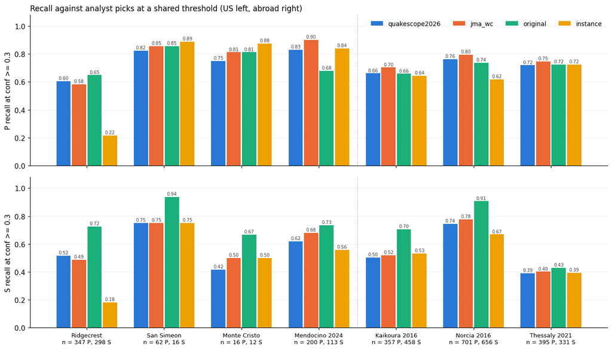

```python
us = load("us_sequences", "recall_at_threshold")
gl = load("global_sequences", "recall_at_threshold")
us["region"], gl["region"] = "US", "abroad"
bench = pd.concat([us, gl], ignore_index=True)
ORDER = [s for s in ["Ridgecrest", "San Simeon", "Monte Cristo", "Mendocino 2024", "Kaikoura 2016", "Norcia 2016", "Thessaly 2021"]
         if s in set(bench.sequence)]

fig, axes = plt.subplots(2, 1, figsize=(12.5, 7.2), sharex=True)
for ax, phase in zip(axes, ("P", "S")):
    sub = bench[bench.phase == phase]
    w = 0.8 / len(WEIGHTS)
    for i, name in enumerate(WEIGHTS):
        xs, ys = [], []
        for j, s in enumerate(ORDER):
            r = sub[(sub.sequence == s) & (sub.weights == name)]
            if len(r):
                xs.append(j + (i - 1.5) * w); ys.append(float(r.recall.iloc[0]))
        ax.bar(xs, ys, width=w * 0.92, color=COLORS[name], label=name)
        for x, y in zip(xs, ys):
            ax.text(x, y + 0.012, f"{y:.2f}", ha="center", fontsize=6.6, color="#3d3d3d")
    ax.set_ylim(0, 1.08); ax.set_ylabel(f"{phase} recall at conf >= 0.3"); ax.grid(axis="x")
axes[0].legend(frameon=False, ncol=4, fontsize=9, loc="upper right")
n_of = lambda s, ph: int(bench[(bench.sequence == s) & (bench.phase == ph)].analyst.iloc[0])
axes[1].set_xticks(range(len(ORDER)))
axes[1].set_xticklabels([f"{s}\nn = {n_of(s, 'P')} P, {n_of(s, 'S')} S" for s in ORDER], fontsize=8.5)
axes[1].axvline(3.5, color="#8a8a8a", lw=0.8, ls=":"); axes[0].axvline(3.5, color="#8a8a8a", lw=0.8, ls=":")
axes[0].set_title("Recall against analyst picks at a shared threshold (US left, abroad right)", loc="left", fontsize=11)
fig.tight_layout()
```

```python
tab = (bench.pivot_table(index=["phase", "sequence"], columns="weights", values="recall")
            .reindex(columns=WEIGHTS).reindex([(p, s) for p in ("P", "S") for s in ORDER]))
tab["analyst"] = [int(bench[(bench.phase == p) & (bench.sequence == s)].analyst.iloc[0]) for p, s in tab.index]
tab.round(3)
```

| phase | weights sequence | quakescope2026 | jma_wc | original | instance | analyst |
| --- | --- | --- | --- | --- | --- | --- |
| P | Ridgecrest | 0.605 | 0.582 | 0.648 | 0.216 | 347 |
|  | San Simeon | 0.823 | 0.855 | 0.855 | 0.887 | 62 |
|  | Monte Cristo | 0.750 | 0.812 | 0.812 | 0.875 | 16 |
|  | Mendocino 2024 | 0.830 | 0.900 | 0.680 | 0.840 | 200 |
|  | Kaikoura 2016 | 0.661 | 0.703 | 0.658 | 0.644 | 357 |
|  | Norcia 2016 | 0.763 | 0.795 | 0.736 | 0.618 | 701 |
|  | Thessaly 2021 | 0.719 | 0.747 | 0.724 | 0.724 | 395 |
| S | Ridgecrest | 0.517 | 0.487 | 0.725 | 0.181 | 298 |
|  | San Simeon | 0.750 | 0.750 | 0.938 | 0.750 | 16 |
|  | Monte Cristo | 0.417 | 0.500 | 0.667 | 0.500 | 12 |
|  | Mendocino 2024 | 0.619 | 0.681 | 0.735 | 0.558 | 113 |
|  | Kaikoura 2016 | 0.502 | 0.520 | 0.705 | 0.533 | 458 |
|  | Norcia 2016 | 0.744 | 0.777 | 0.907 | 0.669 | 656 |
|  | Thessaly 2021 | 0.390 | 0.402 | 0.429 | 0.393 | 331 |

## 2. A threshold is not an operating point

The models' probabilities sit on different scales, so at 0.3 they emit different numbers of picks and the ranking above partly measures liberality. Recall against picks emitted takes the threshold out: each curve is the same model swept from 0.02 to 0.7, and the comparison is made at equal pick counts.

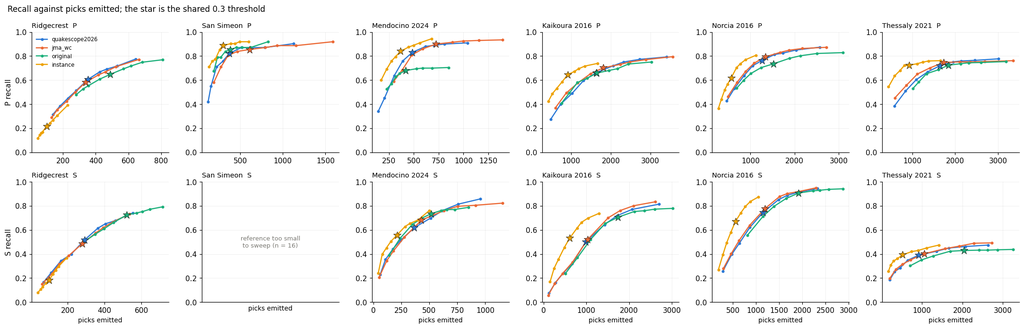

```python
sweep = pd.concat([load("us_sequences", "threshold_sweep").assign(region="US"),
                   load("global_sequences", "threshold_sweep").assign(region="abroad")], ignore_index=True)

seqs = [s for s in ORDER if s in set(sweep.sequence)]
fig, axes = plt.subplots(2, len(seqs), figsize=(3.3 * len(seqs), 6.4), squeeze=False)
for row, phase in enumerate(("P", "S")):
    for ax, s in zip(axes[row], seqs):
        sub = sweep[(sweep.phase == phase) & (sweep.sequence == s)]
        for name in WEIGHTS:
            d = sub[sub.weights == name].sort_values("emitted")
            if not len(d):
                continue
            ax.plot(d.emitted, d.recall, marker="o", ms=3, lw=1.6, color=COLORS[name], label=name)
            star = d[np.isclose(d.thr, 0.3)]
            if len(star):
                ax.plot(star.emitted, star.recall, marker="*", ms=11, color=COLORS[name], mec="#16150f", mew=0.5, zorder=5)
        ax.set_title(f"{s}  {phase}", fontsize=9.5, loc="left"); ax.set_ylim(0, 1)
        if not len(sub):
            n = int(bench[(bench.sequence == s) & (bench.phase == phase)].analyst.iloc[0])
            ax.text(0.5, 0.5, f"reference too small\nto sweep (n = {n})", ha="center", va="center",
                    transform=ax.transAxes, fontsize=8.5, color="#7a7973")
            ax.set_xticks([])
        if row == 1:
            ax.set_xlabel("picks emitted", fontsize=9)
    axes[row][0].set_ylabel(f"{phase} recall")
axes[0][0].legend(frameon=False, fontsize=7.5)
fig.suptitle("Recall against picks emitted; the star is the shared 0.3 threshold", x=0.01, ha="left", fontsize=11)
fig.tight_layout()
```

### Recall at a matched pick budget

For each sequence and phase, the budget is the midpoint of the range every model can reach, and each model's recall is read off its curve there. This is the table the choice of weights should be made from.

```python
def matched(sweep, phase, sequence, names=WEIGHTS):
    sub = sweep[(sweep.phase == phase) & (sweep.sequence == sequence)]
    present = [n for n in names if n in set(sub.weights)]
    if len(present) < 2:                    # the sweep skips references under 20 picks
        return None
    lo = max(sub[sub.weights == n].emitted.min() for n in present)
    hi = min(sub[sub.weights == n].emitted.max() for n in present)
    if not np.isfinite([lo, hi]).all() or hi <= lo:
        return None
    mid = 0.5 * (lo + hi)
    row = {"budget": int(round(mid))}
    for n in present:
        d = sub[sub.weights == n].sort_values("emitted")
        row[n] = float(np.interp(mid, d.emitted, d.recall))
    return row

rows = []
for phase in ("P", "S"):
    for s in seqs:
        r = matched(sweep, phase, s)
        if r is None:                       # a model tops out below the others' floor
            r = matched(sweep, phase, s, [n for n in WEIGHTS if n != "instance"])
            if r is None:
                continue
            r["instance"] = np.nan
        rows.append(dict(phase=phase, sequence=s, **r))
budget = pd.DataFrame(rows).set_index(["phase", "sequence"])
budget.round(3)
```

| phase | sequence | budget | quakescope2026 | jma_wc | original | instance |
| --- | --- | --- | --- | --- | --- | --- |
| P | Ridgecrest | 462 | 0.689 | 0.671 | 0.631 | NaN |
|  | San Simeon | 395 | 0.830 | 0.817 | 0.857 | 0.903 |
|  | Mendocino 2024 | 490 | 0.832 | 0.814 | 0.690 | 0.888 |
|  | Kaikoura 2016 | 1214 | 0.560 | 0.587 | 0.588 | 0.698 |
|  | Norcia 2016 | 910 | 0.660 | 0.680 | 0.621 | 0.773 |
|  | Thessaly 2021 | 1333 | 0.662 | 0.688 | 0.653 | 0.756 |
| S | Ridgecrest | 411 | 0.654 | 0.635 | 0.624 | NaN |
|  | Mendocino 2024 | 320 | 0.580 | 0.579 | 0.616 | 0.650 |
|  | Kaikoura 2016 | 902 | 0.452 | 0.452 | 0.423 | 0.667 |
|  | Norcia 2016 | 936 | 0.651 | 0.669 | 0.612 | 0.849 |
|  | Thessaly 2021 | 1063 | 0.401 | 0.403 | 0.359 | 0.445 |

Blank `instance` cells are sequences where it cannot reach the others' pick counts even with its threshold on the floor: a ceiling, not a calibration offset, and the reason it is not the default weight despite winning most of the matched comparisons where it does reach.

```
mean difference at matched budget: P -0.004, S -0.000; positive in 5 of 11 cases
```

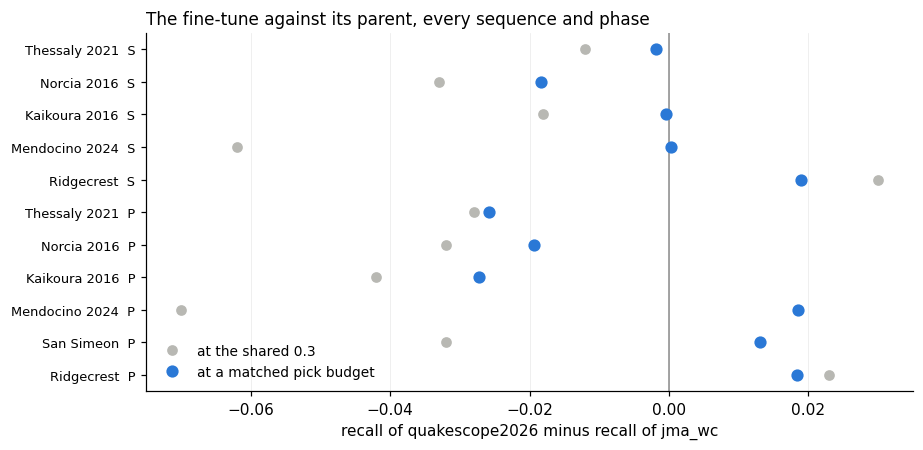

```python
pair = budget.dropna(subset=["quakescope2026", "jma_wc"]).copy()
pair["v7 minus jma_wc, matched budget"] = pair.quakescope2026 - pair.jma_wc
at_thr = bench.pivot_table(index=["phase", "sequence"], columns="weights", values="recall")
pair["v7 minus jma_wc, at 0.3"] = (at_thr.quakescope2026 - at_thr.jma_wc).reindex(pair.index)

fig, ax = plt.subplots(figsize=(8.5, 4.2))
y = np.arange(len(pair))
ax.axvline(0, color="#8a8a8a", lw=1)
ax.plot(pair["v7 minus jma_wc, at 0.3"], y, marker="o", ls="none", ms=6, color="#b8b8b3", label="at the shared 0.3")
ax.plot(pair["v7 minus jma_wc, matched budget"], y, marker="o", ls="none", ms=7, color="#2a78d6", label="at a matched pick budget")
ax.set_yticks(y); ax.set_yticklabels([f"{s}  {p}" for p, s in pair.index], fontsize=8.5)
ax.set_xlabel("recall of quakescope2026 minus recall of jma_wc"); ax.grid(axis="y")
ax.legend(frameon=False, fontsize=9, loc="lower left")
ax.set_title("The fine-tune against its parent, every sequence and phase", loc="left", fontsize=11)
fig.tight_layout()
print(f"mean difference at matched budget: P {pair.xs('P')['v7 minus jma_wc, matched budget'].mean():+.3f}, "
      f"S {pair.xs('S')['v7 minus jma_wc, matched budget'].mean():+.3f}; "
      f"positive in {(pair['v7 minus jma_wc, matched budget'] > 0).sum()} of {len(pair)} cases")
```

## 3. Timing

Mean absolute residual of matched picks against the analyst time at the shared threshold. The fine-tune was selected on timing; this is where an edge would show.

```python
mae = bench.pivot_table(index=["phase", "sequence"], columns="weights", values="MAE").reindex(columns=WEIGHTS)
mae = mae.reindex([(p, s) for p in ("P", "S") for s in ORDER])
(mae * 1000).round(0).astype("Int64").rename(columns=lambda c: f"{c} (ms)")
```

| phase | weights sequence | quakescope2026 (ms) | jma_wc (ms) | original (ms) | instance (ms) |
| --- | --- | --- | --- | --- | --- |
| P | Ridgecrest | 40 | 33 | 58 | 48 |
|  | San Simeon | 67 | 66 | 58 | 83 |
|  | Monte Cristo | 47 | 51 | 49 | 89 |
|  | Mendocino 2024 | 71 | 74 | 119 | 89 |
|  | Kaikoura 2016 | 139 | 139 | 154 | 141 |
|  | Norcia 2016 | 49 | 48 | 57 | 56 |
|  | Thessaly 2021 | 129 | 135 | 139 | 139 |
| S | Ridgecrest | 53 | 64 | 66 | 79 |
|  | San Simeon | 20 | 35 | 103 | 94 |
|  | Monte Cristo | 219 | 236 | 146 | 174 |
|  | Mendocino 2024 | 86 | 101 | 124 | 120 |
|  | Kaikoura 2016 | 162 | 163 | 177 | 166 |
|  | Norcia 2016 | 64 | 69 | 85 | 76 |
|  | Thessaly 2021 | 129 | 132 | 146 | 148 |

## 4. Dense aftershocks, one station cluster

A separate, smaller benchmark on a 30 min Ridgecrest window with overlapping events, scored the same way; its tolerance sweep shows the recall numbers are not sensitive to the matching window between 0.25 and 2 s.

```python
ra = load("ridgecrest_aftershocks", "recall_at_threshold")
sens = load("ridgecrest_aftershocks", "tolerance_sensitivity")
display(ra.pivot(index="weights", columns="phase", values=["analyst", "recall", "MAE"]).reindex(WEIGHTS).round(3))
sens.set_index("tolerance_s").round(3)
```

| phase weights | analyst P | analyst S | recall P | recall S | MAE P | MAE S |
| --- | --- | --- | --- | --- | --- | --- |
| quakescope2026 | 125.0 | 144.0 | 0.928 | 0.792 | 0.034 | 0.045 |
| jma_wc | 125.0 | 144.0 | 0.936 | 0.806 | 0.030 | 0.053 |
| original | 125.0 | 144.0 | 0.872 | 0.868 | 0.037 | 0.056 |
| instance | 125.0 | 144.0 | 0.784 | 0.729 | 0.036 | 0.080 |

| tolerance_s | quakescope2026 | jma_wc | original | instance |
| --- | --- | --- | --- | --- |
| 0.25 | 0.792 | 0.799 | 0.868 | 0.715 |
| 0.50 | 0.792 | 0.806 | 0.868 | 0.729 |
| 1.00 | 0.792 | 0.806 | 0.868 | 0.729 |
| 2.00 | 0.792 | 0.806 | 0.868 | 0.729 |

## 5. Ocean-bottom stations

Three questions, three references. Do OBS-trained weights beat land weights on OBS data (iasp91-predicted P within 10 s, three deployments)? Do the `obs` campaign's stored picks agree with published analyst picks (Barcheck's AACSE tables, 1 s)? And what happens on caldera microseismicity (Axial Seamount, against the UW real-time picks and the LDEO ML-DD events)?

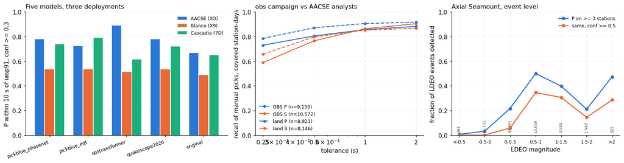

```python
det = load("obs_offshore", "detection_vs_iasp91")
aacse = load("obs_offshore", "aacse_campaign_vs_analyst")
resc = pd.read_csv(RES / "obs_offshore" / "aacse_rescoring.csv", header=[0, 1])
resc.columns = [a if b.startswith("Unnamed") or b == "P_median_dt" and a == "median_P_dt_s" else f"{a} {b}" for a, b in resc.columns]
resc = resc.rename(columns={resc.columns[0]: "weights"}).set_index("weights")
axial = load("obs_offshore", "axial_event_detection_by_magnitude")

fig, axes = plt.subplots(1, 3, figsize=(15, 4), gridspec_kw=dict(width_ratios=[1.2, 1, 1]))

ax = axes[0]
piv = det.pivot(index="weights", columns="experiment", values="rate")
piv = piv.reindex(["pickblue_phasenet", "pickblue_eqt", "obstransformer", "quakescope2026", "original"])
x = np.arange(len(piv)); w = 0.26
for k, (exp, c) in enumerate(zip(piv.columns, ["#2a78d6", "#eb6834", "#1baf7a"])):
    ax.bar(x + (k - 1) * w, piv[exp], width=w * 0.92, color=c, label=exp)
ax.set_xticks(x); ax.set_xticklabels(piv.index, rotation=20, ha="right", fontsize=8)
ax.set_ylim(0, 1); ax.set_ylabel("P within 10 s of iasp91, conf >= 0.3"); ax.legend(frameon=False, fontsize=8)
ax.set_title("Five models, three deployments", loc="left", fontsize=10.5); ax.grid(axis="x")

ax = axes[1]
tols = [0.25, 0.5, 1.0, 2.0]
for _, r in aacse.iterrows():
    ax.plot(tols, [r[f"recall_{t:g}s"] for t in tols], marker="o", ms=4, lw=1.6,
            color=C_P if r.pha == "P" else C_S, ls="-" if r.stations == "OBS" else "--",
            label=f"{r.stations} {r.pha} (n={int(r.n):,})")
ax.set_xscale("log"); ax.set_xticks(tols); ax.set_xticklabels([f"{t:g}" for t in tols])
ax.set_xlabel("tolerance (s)"); ax.set_ylabel("recall of manual picks, covered station-days"); ax.set_ylim(0, 1)
ax.legend(frameon=False, fontsize=8); ax.set_title("obs campaign vs AACSE analysts", loc="left", fontsize=10.5)

ax = axes[2]
ax.plot(range(len(axial)), axial.detected, marker="o", ms=5, lw=1.8, color="#2a78d6", label="P on >= 3 stations")
ax.plot(range(len(axial)), axial.detected_conf05, marker="o", ms=5, lw=1.8, color="#eb6834", label="same, conf >= 0.5")
for i, n in enumerate(axial.n):
    ax.text(i, 0.02, f"{int(n):,}", ha="center", fontsize=6.5, color="#555", rotation=90, va="bottom")
ax.set_xticks(range(len(axial))); ax.set_xticklabels(axial.magnitude, fontsize=8); ax.set_xlabel("LDEO magnitude")
ax.set_ylim(0, 1); ax.set_ylabel("fraction of LDEO events detected"); ax.legend(frameon=False, fontsize=8)
ax.set_title("Axial Seamount, event level", loc="left", fontsize=10.5)
fig.tight_layout()
```

```python
print("AACSE 2018: the five models re-scored on the same analyst windows, plus the campaign's stored pick")
resc.round(3)
```

```
AACSE 2018: the five models re-scored on the same analyst windows, plus the campaign's stored pick
```

| weights | conf>=0.3 P | conf>=0.3 S | conf>=0.2 P | conf>=0.2 S | median_P_dt_s |
| --- | --- | --- | --- | --- | --- |
| pickblue_phasenet | 0.695 | 0.651 | 0.770 | 0.737 | 0.03 |
| pickblue_eqt | 0.652 | 0.569 | 0.735 | 0.675 | 0.04 |
| obstransformer | 0.752 | 0.842 | 0.805 | 0.866 | 0.07 |
| quakescope2026 | 0.638 | 0.292 | 0.742 | 0.459 | 0.06 |
| original | 0.448 | 0.478 | 0.488 | 0.560 | 0.10 |
| campaign (stored) | 0.802 | 0.703 | 0.825 | 0.809 | 0.01 |

## 6. Does the stored catalogue reproduce?

Station-days of the `western` campaign re-picked through the production code path with ObsPy/FDSN as the data source on a different CPU architecture, and matched to the stored Parquet on (station, band, phase, peak time) exactly.

```
33 of 52 targeted station-days hold campaign picks; on those:
  campaign picks 59,315, re-picked 69,063, matched exactly 59,298 (99.9713% of the campaign's), campaign-only 17, re-pick-only 9,765
```

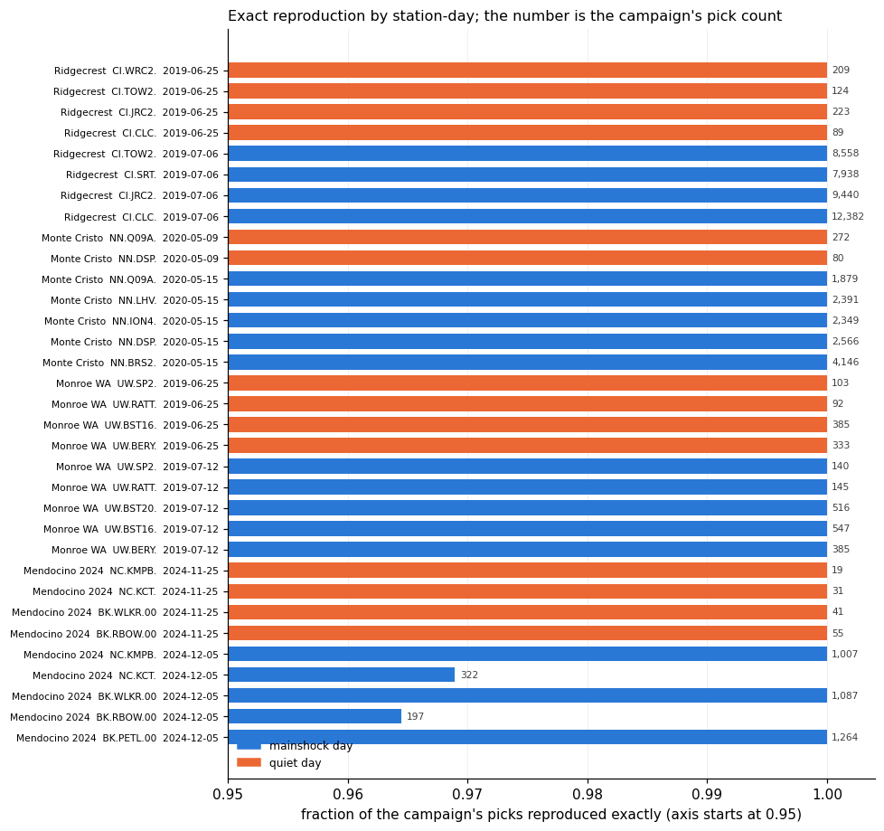

```python
rep = load("western_reproduction", "per_station_day")
if rep is None:
    print("western_reproduction/ not present: execute tutorials/western_pick_validation.ipynb first")
else:
    m = meta["western_reproduction"]["totals"]
    print(f"{m['station_days_with_picks']} of {m['station_days_targeted']} targeted station-days hold campaign picks; on those:")
    print(f"  campaign picks {m['campaign_picks']:,}, re-picked {m['repicked']:,}, matched exactly {m['matched_exact']:,} "
          f"({m['matched_exact'] / m['campaign_picks']:.4%} of the campaign's), campaign-only {m['campaign_only']}, re-pick-only {m['repick_only']:,}")
    r = rep[rep.n_prod > 0].sort_values(["sequence", "kind", "tid"]).reset_index(drop=True)
    fig, ax = plt.subplots(figsize=(9, 0.22 * len(r) + 1.2))
    y = np.arange(len(r))
    ax.barh(y, r.recall, color=[C_P if k == "mainshock" else C_S for k in r.kind], height=0.72)
    for i, row in r.iterrows():
        ax.text(min(row.recall, 1.0) + 0.0004, i, f"{int(row.n_prod):,}", va="center", fontsize=7, color="#3d3d3d")
    ax.set_yticks(y); ax.set_yticklabels([f"{a}  {b}  {c}" for a, b, c in zip(r.sequence, r.tid, r.day)], fontsize=7)
    ax.set_xlim(0.95, 1.004); ax.set_xlabel("fraction of the campaign's picks reproduced exactly (axis starts at 0.95)")
    ax.legend(handles=[plt.Rectangle((0, 0), 1, 1, color=C_P, label="mainshock day"),
                       plt.Rectangle((0, 0), 1, 1, color=C_S, label="quiet day")], frameon=False, fontsize=8, loc="lower left")
    ax.set_title("Exact reproduction by station-day; the number is the campaign's pick count", loc="left", fontsize=10.5)
    ax.grid(axis="y"); fig.tight_layout()
```

## 7. Everything in one table

```python
summary = budget.copy()
summary["n_analyst"] = [int(bench[(bench.phase == p) & (bench.sequence == s)].analyst.iloc[0]) for p, s in summary.index]
summary["study"] = ["global_sequences" if bench[bench.sequence == s].region.iloc[0] == "abroad" else "us_sequences"
                    for p, s in summary.index]
cols = ["budget", "n_analyst"] + WEIGHTS + ["study"]
summary = summary[cols]
summary.to_csv(RES / "summary_matched_budget.csv")
summary.round(3)
```

| phase | sequence | budget | n_analyst | quakescope2026 | jma_wc | original | instance | study |
| --- | --- | --- | --- | --- | --- | --- | --- | --- |
| P | Ridgecrest | 462 | 347 | 0.689 | 0.671 | 0.631 | NaN | us_sequences |
|  | San Simeon | 395 | 62 | 0.830 | 0.817 | 0.857 | 0.903 | us_sequences |
|  | Mendocino 2024 | 490 | 200 | 0.832 | 0.814 | 0.690 | 0.888 | us_sequences |
|  | Kaikoura 2016 | 1214 | 357 | 0.560 | 0.587 | 0.588 | 0.698 | global_sequences |
|  | Norcia 2016 | 910 | 701 | 0.660 | 0.680 | 0.621 | 0.773 | global_sequences |
|  | Thessaly 2021 | 1333 | 395 | 0.662 | 0.688 | 0.653 | 0.756 | global_sequences |
| S | Ridgecrest | 411 | 298 | 0.654 | 0.635 | 0.624 | NaN | us_sequences |
|  | Mendocino 2024 | 320 | 113 | 0.580 | 0.579 | 0.616 | 0.650 | us_sequences |
|  | Kaikoura 2016 | 902 | 458 | 0.452 | 0.452 | 0.423 | 0.667 | global_sequences |
|  | Norcia 2016 | 936 | 656 | 0.651 | 0.669 | 0.612 | 0.849 | global_sequences |
|  | Thessaly 2021 | 1063 | 331 | 0.401 | 0.403 | 0.359 | 0.445 | global_sequences |

Regenerate: execute the five benchmark notebooks (their runtimes are in [`reports/README.md`](https://github.com/SeisSCOPED/QuakeScope/blob/main/reports/README.md)), each of which writes its tables to `docs/benchmark/results/<study>/`, then execute this notebook. `meta.json` in each folder records when and with which SeisBench version.